```python
import ipywidgets as widgets
from IPython.display import display, HTML

javascript_functions = {False: "hide()", True: "show()"}
button_descriptions  = {False: "Show code", True: "Hide code"}

def toggle_code(state):
    """Toggles the JavaScript show()/hide() function on the div.input element.
    """

    output_string = "<script>$(\"div.input\").{}</script>"
    output_args   = (javascript_functions[state],)
    output        = output_string.format(*output_args)
    display(HTML(output))

def button_action(value):
    """Calls the toggle_code function and updates the button description.
    """

    state = value.new
    toggle_code(state)
    value.owner.description = button_descriptions[state]

state = False
toggle_code(state)

button = widgets.ToggleButton(state, description = button_descriptions[state])
button.observe(button_action, "value")

display(button)
```

MSDS 2021 | Big Data and Cloud Computing  
COVID-19 AND THE BLUE SKY  
Exploring COVID-19 Lockdown Effects on the  
Air Quality of Countries Around the Globe

# EXECUTIVE SUMMARY

The COVID-19 pandemic has pushed countries to implement extreme measures that limited human mobility, severely restricting economic activity, just to contain and prevent further spread of the virus. On the other hand, all these happenings’ unintended upside effect was the vast improvement of air quality worldwide. During the lockdown, there have been reports emerging across the globe of blue skies becoming visible, in some cases for the first time in people’s lifetime. **This study explores the impact of interventions brought about by the COVID-19 pandemic on the quality of air in various countries.**

# INTRODUCTION

COVID-19 is an infectious disease caused by a newly discovered coronavirus that affected everyone’s life in one way or another this 2020. COVID-19’s impact has brought unforeseen challenges to various aspects and areas of running a country, but mostly, the pandemic has taken a significant toll on people all across the globe. Given such a massive effect, countries implemented extreme measures and precautions such as lockdowns, closing of borders, banning social gatherings, and more just to halt further spread of the virus. But even before the pandemic, one of the most severe global crises of our time that many countries have been battling for decades is air pollution and the health issues it brings.

According to the World Health Organization (WHO), Air Pollution, also known as the Silent Killer, amasses 7 million lives each year. More than 50% of the deaths happen in South-East Asia and the Western Pacific Region [1]. This is followed by Africa, and then by the Eastern Mediterranean, European, and Americas Region, with the Americas having the least number of deaths per year. The State of Global Air 2019 report actually states that air pollution was the fifth leading risk factor for mortality worldwide in 2017. The WHO also adds that 9 out of 10 people worldwide breathe or are exposed to polluted air. But how did the pandemic affect the world from the environment’s perspective? The surprising effect that the pandemic had on our air quality was rather unexpected. With the recent lockdown, researchers have noticed a significant improvement in terms of air quality. It is intuitive to assume that due to reduced use of transportation and the decrease in manufacturing operations for certain products might have contributed to the air quality improvement. But did the lockdown really translate into lower levels of harmful air pollutants? At the same time, emerging evidence suggests that air pollution worsens the virus’s health impacts, making people more susceptible to COVID-19, and contributing to its transmission.

[figure not shown]

# DATA DESCRIPTION

```python
!aws s3 ls s3://openaq-fetches/ --no-sign-request --human-readable
```

```
                           PRE daily/
                           PRE realtime-gzipped/
                           PRE realtime-parquet-gzipped/
                           PRE realtime/
                           PRE test-realtime-events/
                           PRE test-realtime-gzip/
                           PRE test-realtime/
2017-11-13 17:22:22   24.9 KiB index.html
```

The bucket consists of the various folders. However, all these folders contain files for different ranges of years for example 2017-2018 or 2015-present. To conform with the temporal scope of this project, only the `realtime` folder was used. The folder had subfolders for each day from 2017-12-28 until present. Each folder had multiple `ndjson files` with collected data from all across the globe. Each file consisted of the following columns:

1. **`Date` :** Values were in dictitionary form with 2 keys for the local time and the coordinated universal time. The keys does not follow a standard order, however.
2. **`Parameter` :** The parameter being measured. It is one of the following
   - pm25 - Particulate Matter <2.5 μm
   - pm10 - Particulate Matter <10 μm
   - so2 - Sulfur Dioxide
   - co - Carbon Monoxide
   - no2 - Nitrogen Dioxide
   - o3 - Ozone
   - bc - Black Carbon
3. **`Value` :** Float value of paramter reading.
4. **`Unit` :** Unit of measurement ($ppm$ or $μg/m^3$). The various gaseous parameters have different units of measurement but the non gaseous parameters were consistent with $μg/m^3$.
5. **`averagingPeriod` :** A disctionary of the value and unit between measurement intervals for averaging. Ex. {'value':1, 'unit':'hours'}.
6. **`location` :** The post or building where the measurement was taken.
7. **`city` :** The city where measurement was taken.
8. **`country` :** The ISO-3166 Alpha-2 abbreviation for the country where the measurement was taken.
9. **`coordinates` :** Dictionary of latitude and longitude coordinate points.
10. **`attribution` :** Dictionary of name and source of data
11. **`sourceName` :** Source Name
12. **`sourceType` :** Government or Private
13. **`mobile` :** Bool for mobile or not

File type: **`ndjson` file**

Data date update: **`Realtime`**

Source:  
**`Open AQ Registry of Open Data on AWS` *(https://registry.opendata.aws/openaq/)***

# METHODOLOGY

The methodology of the report aims to **explore the Open Air Quality Data and determine the impact of interventions brought about by the COVID-19 pandemic on the quality of air in various countries.** The challenge of being able to do an exploratory analysis of the the data and understand the underlying behavior within the data deals with delving into the dataset obtained online. The analysis workflow (as illustrated in **Figure 1**) for doing the exploratory and descriptive analysis involves:

1. **Data Retrieval/Collection** - We started by setting up our AWS EC2 instance in order to be able to read data from the S3 bucket. A scheduler with 3 workers were set-up to do the tasks. Retrieved data was in `.ndjson` format was obtained from the Open AQ (Open Air Quality) data found in the Registry of Open Data on AWS. Data will be read as dask dataframes. Since the data was very big (total size is 381 GB), only one year (Nov 2019 to Nov 2020) worth of data was collected, specifically getting only the 5th, 15th, and 25th realtime air quality measurements from the dataset.
2. **Data Cleaning and Pre-processing** - Once data is collected, data is cleaned and pre-processed by converting data into appropriate data types that will be used for analysis.
3. **Exploratory Data Analysis (EDA)** - Do an exploratory data analysis (EDA) to check trends, patterns, and data behaviour within the data.
4. **Ingihts and Recommendations** - Generate insights based on the results of the analysis. Provide recommendations to further improve the study based on the results.

[figure not shown]

**Figure 1.** Methodology for the Exploratory Data Analysis of Open AQ (Air Quality) Data from Nov 2019 to Nov 2020.

# DATA PROCESSING

## Imports

```python
# import standard libraries.

from dask.distributed import Client
from collections import Counter
from operator import itemgetter

import re
import dask
import json
import glob
import warnings
import itertools
import numpy as np
import pandas as pd
import dask.bag as db
import seaborn as sns
import dask.array as da
import dask.dataframe as dd
import matplotlib.pyplot as plt
from tqdm import tqdm

sns.set_style("darkgrid")
plt.rcParams['axes.grid'] = True
plt.rcParams['figure.figsize'] = 15, 10

%matplotlib inline
warnings.filterwarnings('ignore')
pd.set_option('display.float_format', lambda x: '%.3f' % x)
```

```python
from dask.diagnostics import ProgressBar
pbar = ProgressBar()
pbar.register()
```

## Connecting to AWS Instance

```python
client = Client('18.191.192.201:8786')
client
```

Client

- **Scheduler:** tcp://18.191.192.201:8786

- **Dashboard:** http://18.191.192.201:8787/status

Cluster

- **Workers:** 3

- **Cores:** 12

- **Memory:** 50.37 GB

## Data Retrieval

### Checking the Total File Size

The file that was used has a total size of **15.46 GB**, comprising of **4,017** `ndjson files`.

```python
# #done in aws
m = list(itertools.chain(*[['11', '12'],
                           [str(i).zfill(2) for i in np.arange(1, 12)]]))
f = sorted(list(itertools.chain(*[['2019-'+j+'-'+k if i in [0,1]
                                   else '2020-'+j+'-'+k
                                   for i, j in enumerate(m)]
                                  for k in ['05', '15', '25']])))

# l = list(itertools.chain(*[glob.glob(f'./openaq/realtime/{i}/*.ndjson') for i in f]))
# l2 = ["s3://openaq-fetches"+i[8:] for i in l]
# pd.Series(l2).to_csv('all_files.csv', index=False)
```

```python
%%bash --out output
aws s3 ls s3://openaq-fetches/realtime/ --no-sign-request --human-readable --summarize --recursive
```

```python
df2 = output.split('\n')
df2 = pd.Series(df2)
df2 = df2[:-6].str.split(r"\s+",expand=True)
df2 = df2[df2[4].str.contains('|'.join(f))]
print('Number of files = ', len(df2))
print("Total size %.2f GB" % ((df2[df2[3]=='MiB'][2].astype(float).sum()
                    + df2[df2[3]=='KiB'][2].astype(float).sum()/1000)/1000))
df2.sample(5)
```

```
Number of files =  4017
Total size 15.46 GB
```

|  | 0 | 1 | 2 | 3 | 4 |
| --- | --- | --- | --- | --- | --- |
| 104346 | 2019-11-25 | 06:19:06 | 738.9 | KiB | realtime/2019-11-25/1574662265.ndjson |
| 123171 | 2020-04-05 | 06:59:05 | 471.1 | KiB | realtime/2020-04-05/1586069464.ndjson |
| 101503 | 2019-11-05 | 07:14:26 | 2.3 | MiB | realtime/2019-11-05/1572937865.ndjson |
| 107318 | 2019-12-15 | 22:28:41 | 567.9 | KiB | realtime/2019-12-15/1576448465.ndjson |
| 120258 | 2020-03-15 | 13:46:24 | 722.9 | KiB | realtime/2020-03-15/1584279664.ndjson |

```python
l = pd.read_csv('all_files.csv', squeeze=True).to_list()
l[:2]
```

```
['s3://openaq-fetches/realtime/2019-11-05/1572912065.ndjson',
 's3://openaq-fetches/realtime/2019-11-05/1572912665.ndjson']
```

### Loading the Data

```python
df = dd.read_json(l[0], storage_options={'anon': True})
col_order = df.columns

for i in l[1:]:
    df = df.append(dd.read_json(i, storage_options={'anon': True})[col_order])
```

```python
df.npartitions
```

```
4017
```

```python
df.head()
```

|  | date | parameter | value | unit | averagingPeriod | location | city | country | coordinates | attribution | sourceName | sourceType | mobile |
| --- | --- | --- | --- | --- | --- | --- | --- | --- | --- | --- | --- | --- | --- |
| 0 | {'utc': '2019-11-05T00:00:00.000Z', 'local': '... | pm25 | 39.000 | µg/m³ | {'value': 1, 'unit': 'hours'} | Beijing US Embassy | Beijing | CN | {'latitude': 39.95, 'longitude': 116.47} | [{'name': 'StateAir.net', 'url': 'http://www.s... | Beijing US Embassy | government | False |
| 1 | {'utc': '2019-11-04T23:00:00.000Z', 'local': '... | pm10 | 2.000 | µg/m³ | {'unit': 'hours', 'value': 1} | AD0942A | Escaldes-Engordany | AD | {'latitude': 42.5096939994651, 'longitude': 1.... | [{'name': 'EEA', 'url': 'http://www.eea.europa... | EEA Andorra | government | False |
| 2 | {'utc': '2019-11-04T21:00:00.000Z', 'local': '... | so2 | 0.400 | µg/m³ | {'unit': 'hours', 'value': 1} | FR20029 | Rhône | FR | {'latitude': 45.6638900806203, 'longitude': 4.... | [{'name': 'EEA', 'url': 'http://www.eea.europa... | EEA France | government | False |
| 3 | {'utc': '2019-11-04T23:00:00.000Z', 'local': '... | so2 | 0.059 | µg/m³ | {'unit': 'hours', 'value': 1} | FI00027 | Northern Ostrobothnia | FI | {'latitude': 64.9947299995889, 'longitude': 25... | [{'name': 'EEA', 'url': 'http://www.eea.europa... | EEA Finland | government | False |
| 4 | {'utc': '2019-11-04T22:00:00.000Z', 'local': '... | pm10 | 17.700 | µg/m³ | {'unit': 'hours', 'value': 1} | HR0003A | Osjecko-baranjska | HR | {'latitude': 45.55879166613, 'longitude': 18.6... | [{'name': 'EEA', 'url': 'http://www.eea.europa... | EEA Croatia | government | False |

## Data Cleaning and Wrangling

### Converting to appropriate Data Types

```python
df.date = df.date.map(lambda x: str(x)[str(x).find("': '") +
                                       4:str(x).find("': '")+14])
df.date = dd.to_datetime(df.date, format='%Y/%m/%d')
```

### Getting Latitude and Longitude Data

```python
df['latitude'] = (df.coordinates.map(lambda x:
                                     str(x).partition(': ')[2]
                                     .partition(',')[0])).astype(float)
df['longitude'] = (df.coordinates.map(lambda x:
                                       str(x).partition(': ')[2]
                                       .partition(': ')[2]
                                       .replace('}', ''))).astype(float)
```

# EXPLORATORY DATA ANALYSIS

## Countries with the Most Data Points

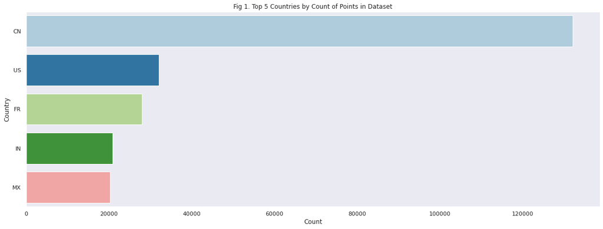

```python
fig, ax = plt.subplots(figsize=(20,7))

fig1 = df['country'].value_counts().compute()[:5].reset_index()
(sns.barplot(x='country', y='index', data=fig1, ax=ax, palette="Paired")
     .set(xlabel="Count", ylabel="Country",
      title='Fig 1. Top 5 Countries by Count of Points in Dataset'));
```

**Figure 1** shows the top 5 countries providing data to OpenAQ. China tops this list by a huge margin.

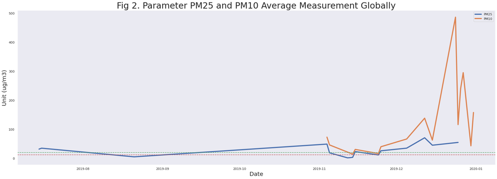

```python
fig, ax = plt.subplots(figsize=(30,10))

(sns.lineplot(x='date', y='value', ax=ax, linewidth = 4,
             data=(df[(df.parameter=='pm25') & (df.value >=0)
                      & (df.date <= '2020')]
                    .groupby('date')['value'].mean().compute().reset_index()),
             label='PM25'))

(sns.lineplot(x='date', y='value', ax=ax, linewidth = 4,
             data=(df[(df.parameter=='pm10') & (df.value >=0)
                      & (df.date <= '2020')]
                    .groupby('date')['value'].mean().compute().reset_index()),
              label='PM10'))
ax.set_title('Fig 2. Parameter PM25 and PM10 Average Measurement Globally',
             fontsize=30);

ax.axhline(y=20, color='g', linestyle='--')
ax.axhline(y=12, color='r', linestyle='--')
ax.set_xlabel('Date', fontsize=20)
ax.set_ylabel('Unit (ug/m3)', fontsize=20);
```

**Figure 2** shows the average measurement of Particulate Matter 2.5 (PM2.5) and Particulate Matter 10 (PM10) of all countries gloablly. The trend shows low reading from Nov 2019 which gradually increased towards 2020. The **green line** shows the safe level for PM10 which is identified by the World Health Organization (WHO) to be 20 ug/m3 while the **red line** is the safe level for PM2.5 which is 12 ug/m3.

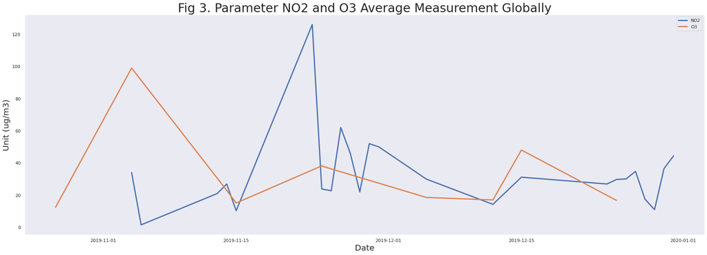

```python
fig, ax = plt.subplots(figsize=(30,10))

(sns.lineplot(x='date', y='value', ax=ax, linewidth = 3,
             data=(df[(df.parameter=='no2') & (df.value >=0)
                      & (df.date >= '2019-09') & (df.date <= '2020')]
                    .groupby('date')['value'].mean().compute().reset_index()),
              label='NO2'))

(sns.lineplot(x='date', y='value', ax=ax, linewidth = 3,
             data=(df[(df.parameter=='o3') & (df.value >=0)
                      & ( df.date >= '2019-09') & (df.date <= '2020')]
                    .groupby('date')['value'].mean().compute().reset_index()),
              label='O3'))

ax.set_title('Fig 3. Parameter NO2 and O3 Average Measurement Globally',
             fontsize=30);
ax.set_xlabel('Date', fontsize=20)
ax.set_ylabel('Unit (ug/m3)', fontsize=20);
```

## China Particulate Matter (PM2.5) Trend from Nov 2019 to Nov 2020

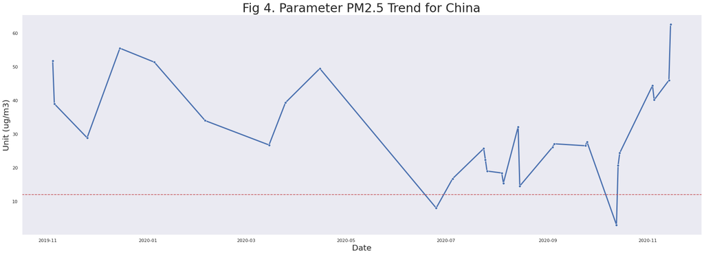

```python
fig, ax = plt.subplots(figsize=(30,10))

(sns.lineplot(x='date', y='value', ax=ax, marker='o', linewidth = 3,
             data=(df[(df.country=='CN') & (df.parameter=='pm25')]
                    .groupby('date')['value'].mean().compute().reset_index()))
)

ax.axhline(y=12, color='r', linestyle='--')
ax.set_title('Fig 4. Parameter PM2.5 Trend for China', fontsize=30)
ax.set_xlabel('Date', fontsize=20)
ax.set_ylabel('Unit (ug/m3)', fontsize=20);
```

**Figure 4** shows the trend of the the PM2.5 air pollutant decreasing at the start of the pandemic and rising back again as life starts to return to normal in China.

# RESULTS & INSIGHTS

First, a descriptive data analysis on the number of measurements submitted for the duration considered was looked at. **Data shows that China is the country that had the most data point submissions followed by countries such as the United States, France, India, and Mexico.** Looking more into the data shows that China has stationed numerous sampling equipment in many cities in their country. Most of the source type of the data points are provided by government agencies, most probably the sectors monitoring ambient air quality in each country.

We then looked at the trends of Particulate Matter 2.5 and 10. Comparing the two (2) meaurements, fine particles (PM2.5) pose the greatest health risk. These fine particles can get deep into lungs and some may even get into the bloodstream. Exposure to these particles can affect a person's lungs and heart. **Despite the lockdown, data shows that certain months in 2019 exceed the safe level prescribed by the World Health Organization which is an average of 12 micrograms per cubic meter of air (μg/m3) or less per day over the duration of a year.**

In addition, NO3 and O3 levels were analyzed. Focusing our lens on NO2, data shows a spike around November of 2019. The main source of nitrogen dioxide (NO2) resulting from human activities is the combustion of fossil fuels (coal, gas and oil) especially fuel used in cars. **Although data seems fluctuating eratically per month, 4th Qtr 2019 going to 2020 has shown a bit of decrease in terms of global average NO2 measurement.**

# CONCLUSION & RECOMMENDATIONS

After conducting the study, it is recommended to further do a deep-dive on the trend and behavior of air quality in terms of other parameters, taking into consideration possible faulty readings (negative readings) from the data. Also, it is recommended to do a look-back beyond 2019 data and check how much air quality have improved from previous years compared to 2020 when most lockdowns were implemented. Given the historical data, it would also be possible to predict air quality of countries in the coming years, also considering the awareness and the studies that link the correlation and the possible effects of air pollution to Covid-19.

# REFERENCES

[1] Air pollution: The silent killer that claims 7 million lives each year. (n.d.). Retrieved November 30, 2020, from https://www.ohchr.org/EN/NewsEvents/Pages/DisplayNews.aspx?NewsID=24248

[2] CCAC secretariat. (2018, May 2). World Health Organization releases new global air pollution data. Retrieved November 30, 2020, from https://www.ccacoalition.org/en/news/world-health-organization-releases-new-global-air-pollution-data

[3] Coronavirus. (n.d.). Retrieved November 30, 2020, from https://www.who.int/health-topics/coronavirus

[4] Liu, F., Wang, M., & Zheng, M. (2020). Effects of COVID-19 lockdown on global air quality and health. Science of The Total Environment, 755, 142533. doi:10.1016/j.scitotenv.2020.142533

[5] Study estimates exposure to air pollution increases COVID-19 deaths by 15% worldwide. (2020, November 27). Retrieved November 30, 2020, from https://www.escardio.org/The-ESC/Press-Office/Press-releases/study-estimates-exposure-to-air-pollution-increases-covid-19-deaths-by-15-world .